# CleanData

# Load Packages

```r
library(tidyverse)
```

```r
library(dplyr)
library(ggplot2)
```

We have to manually download each project file from Boris. Each project is a single aggregated data file and represents one nest (ex. QF01). To download Boris files into a directory for data cleaning, do the following: 1) Open project file in BORIS 2) Observations -> Export Events -> Aggregated events 3) Press select all and then ok 4) Select all subjects then all behaviors, press ok 5) Group selected events into one file 6) Save file as nest name eg. “QF01” as a .csv file in the BORISfiles directory *Note: all state events must be paired to export as an aggregated file* Note: these files do not include observations that did not contain scored behaviors and do not include bees with no observed behaviors

# Load Data

use your own git_filepath to the SarroFisher github repo to access datafiles contained within the repo

```r
## Erica's Git filepath
git_filepath <- ("/Users/ericasarro/Documents/UCR_Code/SarroFisher")

## Kaleigh's Git filepath
#git_filepath <- list_filenames("/Users/kaleighfisher/Desktop/Boris_files")

## Lauren's Git filepath
#git_filepath <- list_filenames("")
```

import the BORIS datafiles and combine them into a single df called all_data. this contains all the behavioral observations

```r
## function to return list of filenames in BORISfiles folder
  ## use pattern="*.csv", when getting files from google drive stream, there is an extra non-.csv file
  ## use full.names=TRUE so that it reads in files using absolute file path
getBORISfilenames <- function(gitfilepath) {
  filenames <- list.files(paste(gitfilepath, "/Data/BORISfiles", sep = ""),
                          pattern = "*.csv",
                          full.names = TRUE)
  return(filenames)
}

## make the list of filenames
BORISfilenames <- getBORISfilenames(git_filepath)

## loop over the files in the list and import all of them into a single dataframe. rename column names to remove "." and make shorter
all_data <- do.call(rbind, lapply(BORISfilenames,
                                    function(i) {
                                      read.csv(i, header = TRUE,
                                               col.names = c("obsID",
                                                             "obsDate",
                                                             "filename",
                                                             "totalLen",
                                                             "fps",
                                                             "beeID",
                                                             "behav",
                                                             "cat",
                                                             "mod",
                                                             "behavType",
                                                             "start",
                                                             "stop",
                                                             "dur",
                                                             "comStart",
                                                             "comStop"))
                     }
))

all_data
```

| obsID | obsDate | filename | totalLen | fps | beeID | behav | cat | mod | behavType | start | stop | dur | comStart | comStop |
| --- | --- | --- | --- | --- | --- | --- | --- | --- | --- | --- | --- | --- | --- | --- |
| nest\tNF02\t20180703\t19 | 2018-07-03 19:00:18 | /Volumes/GoogleDrive/My Drive/WoodardLab.shared/Kaleigh_Ericas_Awesome_Summer_Experiments/Videos/Rounds1_2/NF/NF02/05_nestNF02_1_20180703_195931.avi | 3598.91 | 22 | Worker 2 (5) | feedsbrood | NA | NA | POINT | 4.855 | 4.855 | NA | NA | NA |
| nest\tNF02\t20180704\t20 | 2018-07-04 20:00:17 | /Volumes/GoogleDrive/My Drive/WoodardLab.shared/Kaleigh_Ericas_Awesome_Summer_Experiments/Videos/AllRounds/NF/NF02/05_nestNF02_1_20180704_200023.avi | 3600.45 | 22 | Worker 1 (1) | feedsbrood | NA | NA | POINT | 29.185 | 29.185 | NA | NA | NA |
| nest\tNF02\t20180703\t19 | 2018-07-03 19:00:18 | /Volumes/GoogleDrive/My Drive/WoodardLab.shared/Kaleigh_Ericas_Awesome_Summer_Experiments/Videos/Rounds1_2/NF/NF02/05_nestNF02_1_20180703_195931.avi | 3598.91 | 22 | Worker 2 (5) | feedsbrood | NA | NA | POINT | 50.278 | 50.278 | NA | NA | NA |
| nest\tNF02\t20180703\t19 | 2018-07-03 19:00:18 | /Volumes/GoogleDrive/My Drive/WoodardLab.shared/Kaleigh_Ericas_Awesome_Summer_Experiments/Videos/Rounds1_2/NF/NF02/05_nestNF02_1_20180703_195931.avi | 3598.91 | 22 | Worker 1 (1) | feedsbrood | NA | NA | POINT | 52.828 | 52.828 | NA | NA | NA |
| nest\tNF02\t20180703\t16 | 2018-07-03 16:00:21 | /Volumes/GoogleDrive/My Drive/WoodardLab.shared/Kaleigh_Ericas_Awesome_Summer_Experiments/Videos/AllRounds/NF/NF02/05_nestNF02_1_20180703_165923.avi | 3594.86 | 22 | Worker 1 (1) | feedsbrood | NA | NA | POINT | 56.979 | 56.979 | NA | NA | NA |
| nest\tNF02\t20180704\t2 | 2018-07-04 02:00:19 | /Volumes/GoogleDrive/My Drive/WoodardLab.shared/Kaleigh_Ericas_Awesome_Summer_Experiments/Videos/AllRounds/NF/NF02/05_nestNF02_1_20180704_025944.avi | 3598.55 | 22 | Worker 3 (26) | feedsbrood | NA | NA | POINT | 64.479 | 64.479 | NA | NA | NA |
| nest\tNF02\t20180704\t2 | 2018-07-04 02:00:19 | /Volumes/GoogleDrive/My Drive/WoodardLab.shared/Kaleigh_Ericas_Awesome_Summer_Experiments/Videos/AllRounds/NF/NF02/05_nestNF02_1_20180704_025944.avi | 3598.55 | 22 | Worker 1 (1) | feedsbrood | NA | NA | POINT | 66.626 | 66.626 | NA | NA | NA |
| nest\tNF02\t20180704\t20 | 2018-07-04 20:00:17 | /Volumes/GoogleDrive/My Drive/WoodardLab.shared/Kaleigh_Ericas_Awesome_Summer_Experiments/Videos/AllRounds/NF/NF02/05_nestNF02_1_20180704_200023.avi | 3600.45 | 22 | Worker 5 (77) | feedsbrood | NA | NA | POINT | 98.528 | 98.528 | NA | NA | NA |
| nest\tNF02\t20180703\t19 | 2018-07-03 19:00:18 | /Volumes/GoogleDrive/My Drive/WoodardLab.shared/Kaleigh_Ericas_Awesome_Summer_Experiments/Videos/Rounds1_2/NF/NF02/05_nestNF02_1_20180703_195931.avi | 3598.91 | 22 | Worker 1 (1) | feedsbrood | NA | NA | POINT | 122.225 | 122.225 | NA | NA | NA |
| nest\tNF02\t20180703\t20 | 2018-07-03 20:00:59 | /Volumes/GoogleDrive/My Drive/WoodardLab.shared/Kaleigh & Erica's Awesome Summer Experiments/Videos/*Round1/NF/NF02/05_nestNF02_1_20180703_205932.avi | 3600.09 | 22 | Worker 1 (1) | feedsbrood | NA | NA | POINT | 132.501 | 132.501 | NA | NA | NA |

[output cut: 2267 more lines]

import the master datasheets and combine them into a single df called master_dat. this contains beeIDs and natal colony for each nest. this will enable us to include the bees that we did not have observed behaviors for in our analyses

```r
## do the same for the master datasheets that contain bee ID numbers
getMasterfilenames <- function(gitfilepath) {
  filenames <- list.files(paste(gitfilepath, "/Data/MasterDatasheets", sep = ""),
                          pattern = "*.csv",
                          full.names = TRUE)
  return(filenames)
}

## make the list of filenames
masterfilenames <- getMasterfilenames(git_filepath)

## loop over the files and import all of them. rename column names to remove "." and make shorter
master_data <- do.call(rbind, lapply(masterfilenames,
                                    function(i) {
                                      read.csv(i,
                                               header = FALSE,
                                               skip = 1,
                                               na.strings=c("", " ", "NA", "na", "x", "X", "xp", "-", "#VALUE!", "Died", "died"),
                                               col.names = c("nestID",
                                                             "Qnatal",
                                                             "Qpulled",
                                                             "QID",
                                                             "Gas1",
                                                             "Gas2",
                                                             "Wnatal",
                                                             "Wpulled",
                                                             "WID1",
                                                             "WID2",
                                                             "WID3",
                                                             "WID4",
                                                             "WID5",
                                                             "Eggs",
                                                             "DaysToEggs",
                                                             "LarvDate",
                                                             "FreezeDate",
                                                             "EggsToEclosion",
                                                             "TotalNestTime",
                                                             "Video1",
                                                             "Video2",
                                                             "Notes",
                                                             "MadeBorisFile"))
                     }
))

master_data
```

| nestID | Qnatal | Qpulled | QID | Gas1 | Gas2 | Wnatal | Wpulled | WID1 | WID2 | WID3 | WID4 | WID5 | Eggs | DaysToEggs | LarvDate | FreezeDate | EggsToEclosion | TotalNestTime | Video1 | Video2 | Notes | MadeBorisFile |
| --- | --- | --- | --- | --- | --- | --- | --- | --- | --- | --- | --- | --- | --- | --- | --- | --- | --- | --- | --- | --- | --- | --- |
| QA01 | ES6 | 5.23.18 | NA | 6.4.18 | 6.5.18 | NA | NA | NA | NA | NA | NA | NA | 6.22.18 | 17 | 6.26.18 | 7.22.18 | 30 | 78 | 13.14.15 | gas 3 hr 1st day | Y | NA |
| QA02 | ES6 | 5.23.18 | NA | 6.4.18 | 6.5.18 | NA | NA | NA | NA | NA | NA | NA | 6.19.18 | 14 | 6.23.18 | 7.23.18 | 34 | 7 | 14.15 | gas 3 hr 1st day | Y | NA |
| QA03 | ES6 | 5.23.18 | NA | 6.4.18 | 6.5.18 | NA | NA | NA | NA | NA | NA | NA | 6.26.18 | 21 | 6.30.18 | 7.23.18 | 27 | 789 | 14.15 | gas 3 hr 1st day | Y | NA |
| QA04 | ES6 | 5.29.18 | 50 | 6.10.18 | 6.11.18 | NA | NA | NA | NA | NA | NA | NA | 6.26.18 | 15 | 6.30.18 | 7.28.18 | 32 | 789 | NA | NA | Y | NA |
| QA05 | ES6 | 5.29.18 | 32 | 6.10.18 | 6.11.18 | NA | NA | NA | NA | NA | NA | NA | 6.26.18 | 15 | 6.30.18 | 7.25.18 | 29 | 789 | 14.15 | missing left hind leg :( | Y | NA |
| QT01 | ES7 | 5.29.18 | 66 | 6.10.18 | 6.11.18 | KE1 | 6.11.18 | 18 | 92 | 34 | NA | NA | 6.18.18 | 7 | 6.22.18 | 7.22.18 | 34 | 789 | 13.14.15 | aggression between wkr 92 and queen (66). queen lays eggs 2018.06.29 07:28:12 | Y | NA |
| QT02 | ES6 | 5.30.18 | 85 | 6.11.18 | 6.12.18 | KE1 | 6.12.18 | 2 | 11 | 40 | NA | NA | 6.21.18 | 9 | 6.25.18 | 7.16.18 | 25 | 789 | 13.14.15 | 2 dead workers 6/18 replaced 6/19 (51 & 29, gotten from video) | Y | NA |
| QT03 | ES6 | 6.1.18 | 8 | 6.13.18 | 6.14.18 | KE1 | 6.14.18 | 2 | 67 | 39 | NA | NA | 6.21.18 | 7 | 6.25.18 | 7.20.18 | 29 | 789 | 13.14.15 | NA | Y | NA |
| QT04 | ES6 | 6.1.18 | 62 | 6.13.18 | 6.14.18 | KE1 | 6.14.18 | 32 | 41 | 7 | NA | NA | 6.22.18 | 8 | 6.26.18 | 7.29.18 | 37 | 789 | 13.14 | NA | Y | NA |
| QT05 | NA | NA | NA | NA | NA | NA | NA | NA | NA | NA | NA | NA | NA | NA | NA | NA | NA | NA | NA | NA | N | NA |

[output cut: 66 more lines]

# Clean Data

split obsID column from BORIS all_data into its component parts to enable manipulation by camera/colony/time/date

```r
## convert columns to character to enable manipulation with strsplit() and subset(startsWith())
all_data$beeID <- as.character(all_data$beeID)
all_data$obsID <- as.character(all_data$obsID)

## split out obsID into camID, nestID, dateID and hourID (split based on the tab (\t) between elements)
## element 1 is camID
all_data$camID <- sapply(strsplit(all_data$obsID, "\t"),
                          function(x){
                            x[1]
                            } )
## element 2 is nestID
all_data$nestID <- sapply(strsplit(all_data$obsID, "\t"),
                          function(x){
                            x[2]
                            } )
## element 3 is dateID
all_data$dateID <- sapply(strsplit(all_data$obsID, "\t"),
                          function(x){
                            x[3]
                            } )
## element 4 is hourID
all_data$hourID <- sapply(strsplit(all_data$obsID, "\t"),
                          function(x){
                            x[4]
                            } )

head(all_data)
```

|  | obsID | obsDate | filename | totalLen | fps | beeID | behav | cat | mod | behavType | start | stop | dur | comStart | comStop | camID | nestID | dateID | hourID |
| --- | --- | --- | --- | --- | --- | --- | --- | --- | --- | --- | --- | --- | --- | --- | --- | --- | --- | --- | --- |
| 1 | nest\tNF02\t20180703\t19 | 2018-07-03 19:00:18 | /Volumes/GoogleDrive/My Drive/WoodardLab.shared/Kaleigh_Ericas_Awesome_Summer_Experiments/Videos/Rounds1_2/NF/NF02/05_nestNF02_1_20180703_195931.avi | 3598.91 | 22 | Worker 2 (5) | feedsbrood | NA | NA | POINT | 4.855 | 4.855 | NA | NA | NA | nest | NF02 | 20180703 | 19 |
| 2 | nest\tNF02\t20180704\t20 | 2018-07-04 20:00:17 | /Volumes/GoogleDrive/My Drive/WoodardLab.shared/Kaleigh_Ericas_Awesome_Summer_Experiments/Videos/AllRounds/NF/NF02/05_nestNF02_1_20180704_200023.avi | 3600.45 | 22 | Worker 1 (1) | feedsbrood | NA | NA | POINT | 29.185 | 29.185 | NA | NA | NA | nest | NF02 | 20180704 | 20 |
| 3 | nest\tNF02\t20180703\t19 | 2018-07-03 19:00:18 | /Volumes/GoogleDrive/My Drive/WoodardLab.shared/Kaleigh_Ericas_Awesome_Summer_Experiments/Videos/Rounds1_2/NF/NF02/05_nestNF02_1_20180703_195931.avi | 3598.91 | 22 | Worker 2 (5) | feedsbrood | NA | NA | POINT | 50.278 | 50.278 | NA | NA | NA | nest | NF02 | 20180703 | 19 |
| 4 | nest\tNF02\t20180703\t19 | 2018-07-03 19:00:18 | /Volumes/GoogleDrive/My Drive/WoodardLab.shared/Kaleigh_Ericas_Awesome_Summer_Experiments/Videos/Rounds1_2/NF/NF02/05_nestNF02_1_20180703_195931.avi | 3598.91 | 22 | Worker 1 (1) | feedsbrood | NA | NA | POINT | 52.828 | 52.828 | NA | NA | NA | nest | NF02 | 20180703 | 19 |
| 5 | nest\tNF02\t20180703\t16 | 2018-07-03 16:00:21 | /Volumes/GoogleDrive/My Drive/WoodardLab.shared/Kaleigh_Ericas_Awesome_Summer_Experiments/Videos/AllRounds/NF/NF02/05_nestNF02_1_20180703_165923.avi | 3594.86 | 22 | Worker 1 (1) | feedsbrood | NA | NA | POINT | 56.979 | 56.979 | NA | NA | NA | nest | NF02 | 20180703 | 16 |
| 6 | nest\tNF02\t20180704\t2 | 2018-07-04 02:00:19 | /Volumes/GoogleDrive/My Drive/WoodardLab.shared/Kaleigh_Ericas_Awesome_Summer_Experiments/Videos/AllRounds/NF/NF02/05_nestNF02_1_20180704_025944.avi | 3598.55 | 22 | Worker 3 (26) | feedsbrood | NA | NA | POINT | 64.479 | 64.479 | NA | NA | NA | nest | NF02 | 20180704 | 2 |

### look at how many observations we have for each nest for each BORIS download

These files are updated as more video observations are done. Video observations are performed by many different observers. Check how many videos have been observed for each project for foraging and nest, at the two different time points.

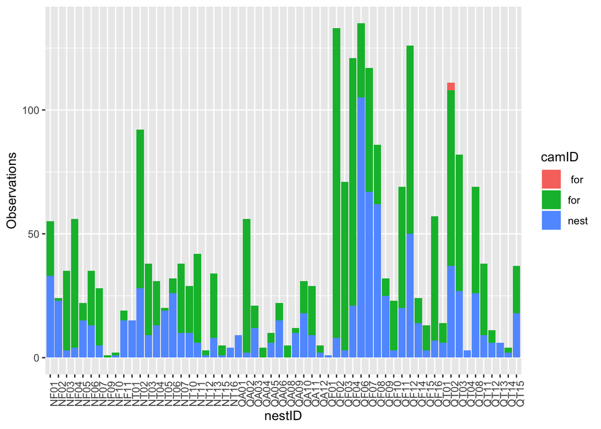

```r
## Make a new column for nest type ie. NT or QT
Queencharacter<-sapply(strsplit(all_data$nestID, ""),
                          function(x){
                            x[1]
                          })
Numbercharacter<-sapply(strsplit(all_data$nestID, ""),
                        function(x){
                          x[2]
                        })

all_data$nestTYPE<-paste0(Queencharacter, Numbercharacter)

##remove first 30 rows because they are labelled incorrectly, Erica is fixing, will not be an issue next download

data_sum<- all_data %>% select(camID, nestID, nestTYPE) %>% arrange(nestID, camID)
datasum<-data_sum[-c(1:30),]

sumsTOTAL<-datasum %>% group_by(nestID, camID) %>% summarise(Observations=n())
sumsTYPE<-datasum %>% group_by(nestTYPE, camID) %>% summarise(Observations=n())

##look at data we have so far based on each colony

ggplot(sumsTOTAL, aes(x=nestID, y=Observations, fill=camID)) +
  geom_bar(stat="identity")+theme(axis.text.x=element_text(angle=90))
```

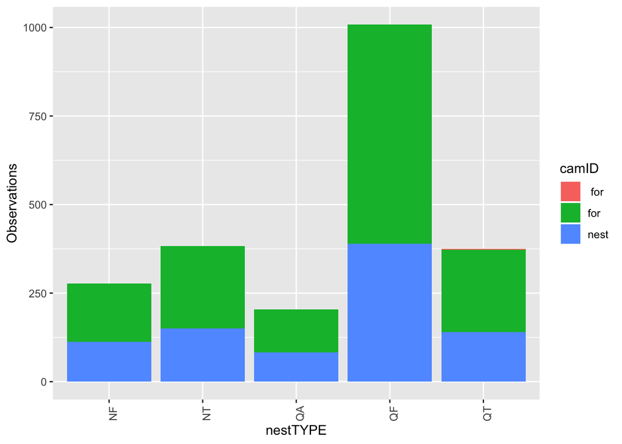

```r
## look at data we have so far based on each type of colony
ggplot(sumsTYPE, aes(x=nestTYPE, y=Observations, fill=camID)) +
  geom_bar(stat="identity")+theme(axis.text.x=element_text(angle=90))
```

### combine master_data and all_data

merge all_data to master_data to add bees who did not carry out any recorded behaviors (ie missing from all_data file)

```r
## subset master_data to only include nests in the all_data file
master_data <- subset(master_data, nestID %in% all_data$nestID)

## make a list of all the bees we do have records for
## select only relevant information
recordedBees <- select(all_data, nestID, beeID)
## remove duplicates
recordedBees <- unique(recordedBees[c("nestID", "beeID")])
## pull out ID number from beeID column
recordedBees$IDnum <- sapply(strsplit(recordedBees$beeID, ")"),
                        function(x){
                          x[1]
                        })
recordedBees$IDnum <- sapply(strsplit(recordedBees$IDnum, "\\("),
                        function(x){
                          x[2]
                        })
## remove NA values
recordedBees <- recordedBees[!is.na(recordedBees$IDnum),]
## combine nestID and IDnum into one variable because some beeIDs are duplicated across nests
recordedBees$ID <- paste(recordedBees$nestID, recordedBees$IDnum)
## list only IDs
recordedBees <- select(recordedBees, ID)

recordedBees
```

|  | ID |
| --- | --- |
| 1 | NF02 5 |
| 2 | NF02 1 |
| 6 | NF02 26 |
| 8 | NF02 77 |
| 25 | NF03 14 |
| 26 | NF03 8 |
| 28 | NF03 90 |
| 60 | NF04 61 |
| 61 | NF04 74 |
| 62 | NF04 44 |

[output cut: 175 more lines]

```r
## format the master_data in the same way as the all_data
## gather the master_data so each worker and queen has their own row
masterBees <- master_data %>%
  gather(QID, WID1, WID2, WID3, WID4, WID5,
         key = "IDtype",
         value = "IDnum")
## remove NA values
masterBees <- masterBees[!is.na(masterBees$IDnum),]
## combine nestID and IDnum into one variable because some beeIDs are duplicated across nests
masterBees$ID <- paste(masterBees$nestID, masterBees$IDnum)
## list only IDs
masterBees <- select(masterBees, ID)

masterBees
```

|  | ID |
| --- | --- |
| 4 | QA04 50 |
| 5 | QA05 32 |
| 6 | QT01 66 |
| 7 | QT02 85 |
| 8 | QT03 8 |
| 9 | QT04 62 |
| 10 | QF01 57 |
| 11 | QF02 12 |
| 12 | QF03 59 |
| 13 | QF04 54 |

[output cut: 211 more lines]

```r
## subset masterBees to only include those not recorded
missingBees <- subset(masterBees, !(ID %in% recordedBees$ID))

## split back out nestID and beeID
missingBees$nestID <- sapply(strsplit(missingBees$ID, " "),
                        function(x){
                          x[1]
                        })
missingBees$beeID <- sapply(strsplit(missingBees$ID, " "),
                        function(x){
                          x[2]
                        })

missingBees
```

|  | ID | nestID | beeID |
| --- | --- | --- | --- |
| 6 | QT01 66 | QT01 | 66 |
| 9 | QT04 62 | QT04 | 62 |
| 10 | QF01 57 | QF01 | 57 |
| 11 | QF02 12 | QF02 | 12 |
| 12 | QF03 59 | QF03 | 59 |
| 27 | QT12 93 | QT12 | 93 |
| 28 | QT13 45 | QT13 | 45 |
| 29 | QT14 97 | QT14 | 97 |
| 33 | QF14 63 | QF14 | 63 |
| 34 | QF15 90 | QF15 | 90 |

[output cut: 41 more lines]

```r
## add missing bees to all_data file
## add rows to all_data, filled with NA values, number of rows equal to number of missingBees
emptydf <- data.frame(matrix(NA, nrow = nrow(missingBees), ncol = ncol(all_data)))
## make column names the same
names(emptydf) <- names(all_data)
## rbind the data. emptydf is at the tail of all_data
all_data <- rbind(all_data, emptydf)
## fill the empty rows just added to all_data with the missing bee nestID and beeID
for (i in 0:(nrow(missingBees) - 1)) {
  all_data$nestID[nrow(all_data) - i] <- missingBees$nestID[i+1]
  all_data$beeID[nrow(all_data) - i] <- missingBees$beeID[i+1]
}

## add random number column to make table compatible with pivot_wider in future steps. needs a unique identifier for each individual
all_data$rand <- NA
for (i in 1:(nrow(all_data))) {
  all_data$rand[i] <- runif(1)
}

## make NA values equal to 0
all_data[is.na(all_data)] <- 0
all_data
```

| obsID | obsDate | filename | totalLen | fps | beeID | behav | cat | mod | behavType | start | stop | dur | comStart | comStop | camID | nestID | dateID | hourID | nestTYPE | rand |
| --- | --- | --- | --- | --- | --- | --- | --- | --- | --- | --- | --- | --- | --- | --- | --- | --- | --- | --- | --- | --- |
| nest\tNF02\t20180703\t19 | 2018-07-03 19:00:18 | /Volumes/GoogleDrive/My Drive/WoodardLab.shared/Kaleigh_Ericas_Awesome_Summer_Experiments/Videos/Rounds1_2/NF/NF02/05_nestNF02_1_20180703_195931.avi | 3598.91 | 22 | Worker 2 (5) | feedsbrood | 0 | 0 | POINT | 4.855 | 4.855 | 0.000 | 0 | 0 | nest | NF02 | 20180703 | 19 | NF | 0.2954735316 |
| nest\tNF02\t20180704\t20 | 2018-07-04 20:00:17 | /Volumes/GoogleDrive/My Drive/WoodardLab.shared/Kaleigh_Ericas_Awesome_Summer_Experiments/Videos/AllRounds/NF/NF02/05_nestNF02_1_20180704_200023.avi | 3600.45 | 22 | Worker 1 (1) | feedsbrood | 0 | 0 | POINT | 29.185 | 29.185 | 0.000 | 0 | 0 | nest | NF02 | 20180704 | 20 | NF | 0.3511441476 |
| nest\tNF02\t20180703\t19 | 2018-07-03 19:00:18 | /Volumes/GoogleDrive/My Drive/WoodardLab.shared/Kaleigh_Ericas_Awesome_Summer_Experiments/Videos/Rounds1_2/NF/NF02/05_nestNF02_1_20180703_195931.avi | 3598.91 | 22 | Worker 2 (5) | feedsbrood | 0 | 0 | POINT | 50.278 | 50.278 | 0.000 | 0 | 0 | nest | NF02 | 20180703 | 19 | NF | 0.4840573850 |
| nest\tNF02\t20180703\t19 | 2018-07-03 19:00:18 | /Volumes/GoogleDrive/My Drive/WoodardLab.shared/Kaleigh_Ericas_Awesome_Summer_Experiments/Videos/Rounds1_2/NF/NF02/05_nestNF02_1_20180703_195931.avi | 3598.91 | 22 | Worker 1 (1) | feedsbrood | 0 | 0 | POINT | 52.828 | 52.828 | 0.000 | 0 | 0 | nest | NF02 | 20180703 | 19 | NF | 0.5101974367 |
| nest\tNF02\t20180703\t16 | 2018-07-03 16:00:21 | /Volumes/GoogleDrive/My Drive/WoodardLab.shared/Kaleigh_Ericas_Awesome_Summer_Experiments/Videos/AllRounds/NF/NF02/05_nestNF02_1_20180703_165923.avi | 3594.86 | 22 | Worker 1 (1) | feedsbrood | 0 | 0 | POINT | 56.979 | 56.979 | 0.000 | 0 | 0 | nest | NF02 | 20180703 | 16 | NF | 0.4247150584 |
| nest\tNF02\t20180704\t2 | 2018-07-04 02:00:19 | /Volumes/GoogleDrive/My Drive/WoodardLab.shared/Kaleigh_Ericas_Awesome_Summer_Experiments/Videos/AllRounds/NF/NF02/05_nestNF02_1_20180704_025944.avi | 3598.55 | 22 | Worker 3 (26) | feedsbrood | 0 | 0 | POINT | 64.479 | 64.479 | 0.000 | 0 | 0 | nest | NF02 | 20180704 | 2 | NF | 0.4899215782 |
| nest\tNF02\t20180704\t2 | 2018-07-04 02:00:19 | /Volumes/GoogleDrive/My Drive/WoodardLab.shared/Kaleigh_Ericas_Awesome_Summer_Experiments/Videos/AllRounds/NF/NF02/05_nestNF02_1_20180704_025944.avi | 3598.55 | 22 | Worker 1 (1) | feedsbrood | 0 | 0 | POINT | 66.626 | 66.626 | 0.000 | 0 | 0 | nest | NF02 | 20180704 | 2 | NF | 0.9212253559 |
| nest\tNF02\t20180704\t20 | 2018-07-04 20:00:17 | /Volumes/GoogleDrive/My Drive/WoodardLab.shared/Kaleigh_Ericas_Awesome_Summer_Experiments/Videos/AllRounds/NF/NF02/05_nestNF02_1_20180704_200023.avi | 3600.45 | 22 | Worker 5 (77) | feedsbrood | 0 | 0 | POINT | 98.528 | 98.528 | 0.000 | 0 | 0 | nest | NF02 | 20180704 | 20 | NF | 0.0147351953 |
| nest\tNF02\t20180703\t19 | 2018-07-03 19:00:18 | /Volumes/GoogleDrive/My Drive/WoodardLab.shared/Kaleigh_Ericas_Awesome_Summer_Experiments/Videos/Rounds1_2/NF/NF02/05_nestNF02_1_20180703_195931.avi | 3598.91 | 22 | Worker 1 (1) | feedsbrood | 0 | 0 | POINT | 122.225 | 122.225 | 0.000 | 0 | 0 | nest | NF02 | 20180703 | 19 | NF | 0.9807962910 |
| nest\tNF02\t20180703\t20 | 2018-07-03 20:00:59 | /Volumes/GoogleDrive/My Drive/WoodardLab.shared/Kaleigh & Erica's Awesome Summer Experiments/Videos/*Round1/NF/NF02/05_nestNF02_1_20180703_205932.avi | 3600.09 | 22 | Worker 1 (1) | feedsbrood | 0 | 0 | POINT | 132.501 | 132.501 | 0.000 | 0 | 0 | nest | NF02 | 20180703 | 20 | NF | 0.2862651590 |

[output cut: 2318 more lines]

### make count data df with counts of each behavior observed for each bee

output df with each bee as a single row, behaviors as columns, count of frequency of each behavior per bee as values

```r
## collapse the dataframe to count the number of instances doing each behavior
  ## this outputs a new dataframe with columns nestID, beeID, nectarforaging, feedsbrood, pollenforaging
  ## (and any other behaviors recorded), with counts for each behavior in as values
  ## assumes rand number is not duplicated across individuals.

## rename to count_data for clarity
count_data <- all_data
## add a column with value 1 that counts the behavioral observations this makes each behavior a count of 1
count_data$count <- 1
## condense data frame into relevant columns, each row is a single observation for an individual
count_data <- count_data %>%
  pivot_wider(id_cols = c("nestID", "beeID", "behav"),
              names_from = rand,
              values_from = count)

## add column to fill with sum of counts for each behav
count_data$totCount <- rowSums(count_data[4:ncol(count_data)], na.rm = TRUE)

## subset dataframe so that all is left is nestID, beeID, behav, and totCount
count_data <- count_data %>%
  select(nestID, beeID, behav, totCount)

## collapse dataframe so that each bee has one single row. cols = nestID, beeID, nectarforaging, *other behaviors
count_data <- count_data %>%
  pivot_wider(id_cols = c("nestID", "beeID"),
              names_from = behav,
              values_from = totCount)

## replace NA values with 0
count_data[is.na(count_data)] <- 0

## sum rows excluding first two (nestID and beeID) to see total number of behaviors carried out by each indiv
count_data$nBehavs <- rowSums(count_data[, 3:ncol(count_data)], na.rm = TRUE)

## add column for queen / worker status based on first letter in beeID
beeTypeCharacter <- sapply(strsplit(count_data$beeID, ""),
                          function(x){
                            x[1]
                          })

count_data$beeType <- beeTypeCharacter

## remove unknown worker data
count_data <- count_data[!count_data$beeType == "U", ]
count_data <- count_data[!count_data$beeType == "N", ]
## make missingBees beeType NA
for (i in 1:nrow(count_data)) {
  if (count_data$beeType[i] == 1 ||
      count_data$beeType[i] == 2 ||
      count_data$beeType[i] == 3 ||
      count_data$beeType[i] == 4 ||
      count_data$beeType[i] == 5 ||
      count_data$beeType[i] == 6 ||
      count_data$beeType[i] == 7 ||
      count_data$beeType[i] == 8 ||
      count_data$beeType[i] == 9) {
    count_data$beeType[i] <- 0
  }
}

##Save dataframe as .csv so it can be used in other downstream analyses
write.csv(count_data, "count_data.csv")

count_data
```

| nestID | beeID | feedsbrood | pollenforaging | nectarforaging | fillshoneypot | other | broodmanipulate | incubate | end | waxmanipulate | offbrood | laysegg | eatsbrood | NA | nBehavs | beeType |
| --- | --- | --- | --- | --- | --- | --- | --- | --- | --- | --- | --- | --- | --- | --- | --- | --- |
| NF02 | Worker 2 (5) | 6 | 0 | 0 | 0 | 0 | 0 | 0 | 0 | 0 | 0 | 0 | 0 | 0 | 6 | W |
| NF02 | Worker 1 (1) | 11 | 0 | 0 | 0 | 0 | 0 | 0 | 0 | 0 | 0 | 0 | 0 | 0 | 11 | W |
| NF02 | Worker 3 (26) | 3 | 0 | 0 | 0 | 0 | 0 | 0 | 0 | 0 | 0 | 0 | 0 | 0 | 3 | W |
| NF02 | Worker 5 (77) | 3 | 0 | 0 | 0 | 0 | 0 | 0 | 0 | 0 | 0 | 0 | 0 | 0 | 3 | W |
| NF03 | Worker 2 (14) | 1 | 0 | 22 | 1 | 0 | 0 | 0 | 0 | 0 | 0 | 0 | 0 | 0 | 24 | W |
| NF03 | Worker 1 (8) | 0 | 0 | 1 | 0 | 0 | 0 | 0 | 0 | 0 | 0 | 0 | 0 | 0 | 1 | W |
| NF03 | Worker 8 (90) | 1 | 9 | 0 | 0 | 0 | 0 | 0 | 0 | 0 | 0 | 0 | 0 | 0 | 10 | W |
| NF04 | Worker 3 (61) | 0 | 2 | 17 | 0 | 0 | 0 | 0 | 0 | 0 | 0 | 0 | 0 | 0 | 19 | W |
| NF04 | Worker 4 (74) | 2 | 1 | 3 | 0 | 0 | 0 | 0 | 0 | 0 | 0 | 0 | 0 | 0 | 6 | W |
| NF04 | Worker 2 (44) | 1 | 0 | 10 | 0 | 0 | 0 | 0 | 0 | 0 | 0 | 0 | 0 | 0 | 11 | W |

[output cut: 233 more lines]

### make duration df with duration of each behavior for each bee

output df with each bee as a single row, behaviors as columns, total duration of each behavior per bee as values

```r
## rename for clarity
dur_data <- all_data


## only look at first 5 minutes of the watched video to standardize. we only ever watched 5 minutes of nest videos,
  ## so remove anything over 5 minutes of foraging video to standardize the amount of video watched in each category

## only look at first 5 minutes (300 seconds) of the watched video to standardize
dur_data$start <- as.numeric(dur_data$start)
dur_data$stop <- as.numeric(dur_data$stop)
dur_data <- dur_data[dur_data$start <= 300, ]
## make behaviors stop at the end of 5 minutes
for (i in 1:(nrow(dur_data))) {
  if (dur_data$stop[i] > 300) {
    dur_data$stop[i] <- 301
  }
}

## recalculate duration data to account for stop time at 5 minutes
for (i in 1:nrow(dur_data)) {
  dur_data$dur[i] <- dur_data$stop[i] - dur_data$start[i]
}

## make duration of all brood feeding events 1 second duration to enable duration comparisons
for (i in 1:nrow(dur_data)) {
  if (!is.na(dur_data$behav[i]) && dur_data$behav[i] == "feedsbrood") {
    dur_data$dur[i] <- 1
  }
}

## collapse dataframe so that columns = nestID, beeID, behav, and stop times for each behavior.
## values = duration of each behav
dur_data <- dur_data %>%
  pivot_wider(id_cols = c("nestID", "beeID", "behav"),
              names_from = rand,
              values_from = dur,
              names_repair = "minimal")

## add column with the sum of durations for each behav
dur_data$totDur <- rowSums(dur_data[4:ncol(dur_data)], na.rm = TRUE)

## subset dataframe so that all is left is nestID, beeID, behav, and totDur
dur_data <- dur_data %>%
  select(nestID, beeID, behav, totDur)

## collapse dataframe so that each bee has one single row. cols = nestID, beeID, nectarforaging, *other behaviors
dur_data <- dur_data %>%
  pivot_wider(id_cols = c("nestID", "beeID"),
              names_from = behav,
              values_from = totDur)

## replace NA values with 0
dur_data[is.na(dur_data)] <- 0

##save dataframe as .csv so it can be used in other downstrea analyses
write.csv(dur_data, "dur_data.csv")

dur_data
```

| nestID | beeID | feedsbrood | nectarforaging | fillshoneypot | pollenforaging | other | broodmanipulate | incubate | end | waxmanipulate | offbrood | laysegg | eatsbrood | NA |
| --- | --- | --- | --- | --- | --- | --- | --- | --- | --- | --- | --- | --- | --- | --- |
| NF02 | Worker 2 (5) | 6 | 0.000 | 0 | 0.000 | 0.000 | 0.000 | 0.000 | 0 | 0.000 | 0.000 | 0.000 | 0.000 | 0 |
| NF02 | Worker 1 (1) | 11 | 0.000 | 0 | 0.000 | 0.000 | 0.000 | 0.000 | 0 | 0.000 | 0.000 | 0.000 | 0.000 | 0 |
| NF02 | Worker 3 (26) | 3 | 0.000 | 0 | 0.000 | 0.000 | 0.000 | 0.000 | 0 | 0.000 | 0.000 | 0.000 | 0.000 | 0 |
| NF02 | Worker 5 (77) | 3 | 0.000 | 0 | 0.000 | 0.000 | 0.000 | 0.000 | 0 | 0.000 | 0.000 | 0.000 | 0.000 | 0 |
| NF03 | Worker 2 (14) | 1 | 237.578 | 0 | 0.000 | 0.000 | 0.000 | 0.000 | 0 | 0.000 | 0.000 | 0.000 | 0.000 | 0 |
| NF03 | Worker 1 (8) | 0 | 188.548 | 0 | 0.000 | 0.000 | 0.000 | 0.000 | 0 | 0.000 | 0.000 | 0.000 | 0.000 | 0 |
| NF03 | Worker 8 (90) | 1 | 0.000 | 0 | 4.277 | 0.000 | 0.000 | 0.000 | 0 | 0.000 | 0.000 | 0.000 | 0.000 | 0 |
| NF04 | Worker 3 (61) | 0 | 79.519 | 0 | 12.240 | 0.000 | 0.000 | 0.000 | 0 | 0.000 | 0.000 | 0.000 | 0.000 | 0 |
| NF04 | Worker 4 (74) | 2 | 299.722 | 0 | 0.000 | 0.000 | 0.000 | 0.000 | 0 | 0.000 | 0.000 | 0.000 | 0.000 | 0 |
| NF04 | Worker 2 (44) | 1 | 249.755 | 0 | 0.000 | 0.000 | 0.000 | 0.000 | 0 | 0.000 | 0.000 | 0.000 | 0.000 | 0 |

[output cut: 239 more lines]

### duration of video watched for each colony

output df with total duration of video watched per colony. columns = nestID and totalLen

```r
## select only the obsID, nestID, and totalLen columns
## subset to only the unique combinations (ie. remove duplicate videos so we don't count more time than we watched)
totalLen_data <- all_data %>%
  select(obsID, nestID, totalLen) %>%
  unique()
totalLen_data
```

|  | obsID | nestID | totalLen |
| --- | --- | --- | --- |
| 1 | nest\tNF02\t20180703\t19 | NF02 | 3598.91 |
| 2 | nest\tNF02\t20180704\t20 | NF02 | 3600.45 |
| 5 | nest\tNF02\t20180703\t16 | NF02 | 3594.86 |
| 6 | nest\tNF02\t20180704\t2 | NF02 | 3598.55 |
| 10 | nest\tNF02\t20180703\t20 | NF02 | 3600.09 |
| 15 | nest\tNF02\t20180703\t13 | NF02 | 3599.27 |
| 21 | nest\tNF02\t20180704\t14 | NF02 | 3599.18 |
| 24 | for\tNF02\t20180704\t10 | NF02 | 3601.44 |
| 25 | for\tNF03\t20180705\t17 | NF03 | 3309.24 |
| 28 | nest\tNF03\t20180629\t5 | NF03 | 2864.24 |

[output cut: 584 more lines]

```r
## split out obsID into camID, dateID and hourID (split based on the tab (\t) between elements)
## element 1 is camID
totalLen_data$camID <- sapply(strsplit(totalLen_data$obsID, "\t"),
                          function(x){
                            x[1]
                            } )
## element 3 is dateID
totalLen_data$dateID <- sapply(strsplit(totalLen_data$obsID, "\t"),
                          function(x){
                            x[3]
                            } )
## element 4 is hourID
totalLen_data$hourID <- sapply(strsplit(totalLen_data$obsID, "\t"),
                          function(x){
                            x[4]
                            } )
## combine date and hour into a single column called timeID
totalLen_data$timeID <- paste(totalLen_data$dateID, totalLen_data$hourID)
## subset the df to remove the obs, hour, and date columns
totalLen_data <- totalLen_data %>%
  select(camID, timeID, nestID, totalLen)
## make totalLen reflect only the first 5 minutes of the video, since we removed observations from after that point
totalLen_data$totalLen[totalLen_data$totalLen > 300] <- 300

totalLen_data
```

|  | camID | timeID | nestID | totalLen |
| --- | --- | --- | --- | --- |
| 1 | nest | 20180703 19 | NF02 | 300.00 |
| 2 | nest | 20180704 20 | NF02 | 300.00 |
| 5 | nest | 20180703 16 | NF02 | 300.00 |
| 6 | nest | 20180704 2 | NF02 | 300.00 |
| 10 | nest | 20180703 20 | NF02 | 300.00 |
| 15 | nest | 20180703 13 | NF02 | 300.00 |
| 21 | nest | 20180704 14 | NF02 | 300.00 |
| 24 | for | 20180704 10 | NF02 | 300.00 |
| 25 | for | 20180705 17 | NF03 | 300.00 |
| 28 | nest | 20180629 5 | NF03 | 300.00 |

[output cut: 584 more lines]

```r
## for each nestID, remove nest videos that have a matching foraging video (i.e. watched twice)
  ##  sum totalLen for all the for videos + nest videos that do not have a matching for video

## create empty dataframe to put length into
camDur <- data.frame(nestID = NA,
                     forLen = NA,
                     nestLen = NA,
                     totalLen = NA)
## for each unique nest, subset the data to look at one nest at a time. then split out foraging and nest videos
## then remove nest videos that have a matching foraging video. then sum total length of remaining nest + for videos
## then add those values to the camDur dataframe
for (i in 1:length(unique(totalLen_data$nestID))) {
  sub_data <- subset(totalLen_data, nestID == unique(totalLen_data$nestID)[i]) # subset to look at a single nest
  for_data <- subset(sub_data, sub_data$camID == "for") # subset to look at foraging video only
  nest_data <- subset(sub_data, sub_data$camID == "nest") # subset to look at nest video only
  subNest_data <- nest_data %>%
      filter(! timeID %in% for_data$timeID) # remove nest videos that have a matching foraging video so we don't double count time
  forSum <- sum(for_data$totalLen) # sum the video duration of all foraging videos
  totNestSum <- sum(nest_data$totalLen) # sum the video duration of all nest videos
  subNestSum <- sum(subNest_data$totalLen) # sum the video duration of all nest videos that don't have a matching foraging video
  camSum <- forSum + subNestSum # sum the video duration of forging + subsetted nest videos
  camDur <- rbind(camDur, c(sub_data$nestID[1], forSum, totNestSum, camSum)) # add the sum totals to the camDur df
}
## remove NA row initially created
camDur <- camDur[2:nrow(camDur),]

## make columns numeric so i can calculate ratio in next step
camDur$totalLen <- as.numeric(camDur$totalLen)
camDur$forLen <- as.numeric(camDur$forLen)
camDur$nestLen <- as.numeric(camDur$nestLen)

## make new column with the ratio of foraging to nest video length. should be ~1 for each colony. if it's not, need to watch more videos
camDur$FNratio <- NA
for (i in 1:nrow(camDur)) {
  camDur$FNratio[i] <- camDur$forLen[i] / camDur$nestLen[i]
}

##Save dataframe as .csv so it can be used in other downstrea analyses
write.csv(camDur, "camDur.csv")

## check to see how much video was watched for each nest and for each treatment
## must be equal + ratio must be 1 to compare
camDur
```

|  | nestID | forLen | nestLen | totalLen | FNratio |
| --- | --- | --- | --- | --- | --- |
| 2 | NF02 | 300.00 | 2100.00 | 2400.00 | 0.1428571 |
| 3 | NF03 | 900.00 | 900.00 | 1800.00 | 1.0000000 |
| 4 | NF04 | 3900.00 | 600.00 | 4500.00 | 6.5000000 |
| 5 | NF05 | 600.00 | 2100.00 | 2400.00 | 0.2857143 |
| 6 | NF06 | 2400.00 | 2400.00 | 3600.00 | 1.0000000 |
| 7 | NF07 | 2100.00 | 1200.00 | 2700.00 | 1.7500000 |
| 8 | 20180815 | 0.00 | 0.00 | 0.00 | NaN |
| 9 | 20180823 | 0.00 | 0.00 | 0.00 | NaN |
| 10 | NF09 | 300.00 | 0.00 | 300.00 | Inf |
| 11 | NF10 | 300.00 | 300.00 | 600.00 | 1.0000000 |

[output cut: 57 more lines]